# Peer-review - Bâtiments de Troyes Champagne Métropole

Maman j’ai raté la vizu

# Introduction

## Étude des bâtiments de Troyes

## Données

Le jeu de données « Bâtiments de Troyes Champagne Métropole » recense l’ensemble des bâtiments situés dans l’agglomération Troyes Champagne Métropole, à des fins variées telles que l’urbanisme, l’aménagement du territoire, les analyses foncières ou encore la gestion des services publics. Il a été publié en août 2024 sur la plateforme data.gouv.fr.

Nous avons choisi ce jeu de données, car il nous semble pertinent d’étudier la répartition géographique des bâtiments dans la ville de Troyes. Afin d’enrichir notre analyse, nous avons décidé d’y associer un second jeu de données : la Base Adresse Nationale (BAN), qui recense les adresses géolocalisées des bâtiments sur l’ensemble du territoire français (nous utiliserons uniquement les adresses du département nous concernant).

### Origines et format des données

La base de données bâtiments est disponible [ici](https://www.data.gouv.fr/fr/datasets/batiments-de-troyes-champagne-metropole/). Ce jeu de données a été commandé par “Troyes Champagne Métropole” et a été mise à jour dernièrement en août 2024 dans le but de regrouper les entités géographiques de la métropole troyenne. Les données proviennent elles-mêmes de deux sources différentes qui ont été fusionnées : BDTOPO® et BD PARCELLAIRE®, les deux étant produits par IGN.

- La BD PARCELLAIRE® fournit l’information cadastrale numérique, géo-référencée et continue sur l’ensemble du territoire français. Elle est réalisée à partir de l’assemblage du plan cadastral dématérialisé. Cependant, elle n’est plus entretenue depuis 2019.
- La BDTOPO® est maintenu depuis 2019, elle couvre de manière cohérente l’ensemble des entités géographiques et administratives du territoire national.

Et la base de données des adresses, un csv par département, est [ici](https://adresse.data.gouv.fr/data/ban/adresses/latest/csv) (adresses-10.csv que nous avons renommé adresses_aube.csv). Les données proviennent de la BAN. Ces données sont initialement destiné aux services d’urgence pour qu’ils puissent se diriger. Elle est aussi destiné au raccord aux réseaux d’énergies ou de communication ou encore pour des analyses cartographiques précises. Sa constitution est copilotée par l’ANCT, la DINUM et l’IGN.

Les liens, quant à eux sont disponibles sur ce [lien](https://geoservices.ign.fr/ban-plus). Produits aussi par IGN, c’est une base de données qui permet de lier la BAN à son environnement géographique.

### Les variables

Dans notre étude, nous allons considérer 16 variables.

#### BATI

Nous avons sélectionné 14 variables dans le premier jeu de données.

| Nom | Type | Description |
| --- | --- | --- |
| NATURE | nominal | architecture du bâtiment |
| USAGE1 | nominal | utilisation du bâtiment (agricole, résidentiel, religieux…) |
| USAGE2 | nominal (optionnel) | utilisation du bâtiment |
| LEGER | discrète | structure légère ou pas |
| DATE_APP | discrète | date d’apparition/construction (pas toujours présent) |
| ACQU_PLANI | nominal | de quelle base provient l’information |
| NB_LOGTS | discrète | nombre de logements dans le bâtiment |
| NB_ETAGES | discrète | nombre d’étages du bâtiment |
| MAT_MURS | discrète | code des matériaux des murs (à croiser avec le csv materiaux_murs.csv) |
| MAT_TOITS | discrète | code des matériaux de la toiture (à croiser avec le csv materiaux_toits.csv) |
| HAUTEUR | continue | hauteur du bâtiment |
| Z_SOL | continue | altitude du sol |
| Z_TOIT | continue | altitude du toit |
| ETAT | nominal | état du bâtiment (en projet, en construction, en service, en ruine) |

#### ADRESSES

Pour la localisation, nous utiliserons 2 variables : la longitude et la latitude.

| Nom | Type | Description |
| --- | --- | --- |
| LONGITUDE | continue | coordonnée GPS |
| LATITUDE | continue | coordonnée GPS |

#### Pourquoi avoir choisi ces variables

Nous avons enlevé les variables qui nous semblaient inutiles ainsi que celles comportant peu de valeurs. Nous avons aussi enlevé les variables que nous n’avons pas trouvées pertinentes.

## Plan d’analyse

### 1. Y a-t-il une liaison entre la hauteur des bâtiments et leur usage ?

Il s’agit de déterminer s’il existe une relation entre la hauteur d’un bâtiment et son usage. Les variables utilisées sont : la variable `hauteur` et la variable `usage1`.

Pour cela, nous envisageons d’utiliser :

- Un diagramme à barres empilées pour étudier la répartition des usages :
  - L’axe des abscisses représenterait les tranches de hauteur
  - L’axe des ordonnées représenterait le nombre de bâtiments
  - Chaque barre avec une répartition des usages

### 2. Comment la ville de Troyes s’est étendue géographiquement au fil des années ?

Il s’agit ici de visualiser l’évolution spatiale de la ville de Troyes au fil du temps. Pour cela, nous utiliserons la variable `date_app` et les variables de coordonnées géographiques : `latitude` et `longitude`.

Comme types de visualisations à envisager, nous avons :

- Une carte avec les bâtiments colorés selon leur date (période) de construction

Les problèmes potentiels :

- l’absence de date de construction pour certains bâtiments

### 3. Y a-t-il un lien entre les matériaux de construction et les dates de construction ?

Il s’agit ici de déterminer s’il existe une relation entre les variables `date_app`, `mat_murs` et `mat_toits`. L’objectif est de vérifier si les matériaux de construction des bâtiments varient en fonction des époques.

Pour cela, nous envisageons deux types de visualisations :

- Un line chart pour suivre l’évolution du nombre de bâtiments par matériau au fil du temps :
  - L’axe des abscisses représenterait les années
  - L’axe des ordonnées représenterait le nombre de bâtiments
  - Chaque ligne représenterait un matériau
- Un violon plot pour étudier la distribution des dates selon chaque matériau :
  - L’axe des abscisses représenterait les années
  - L’axe des ordonnées représenterait les matériaux de construction

  Les problèmes potentiels sont :
  - un grand nombre de catégories de matériaux (risque de graphe illisible)

### 4. Y a-t-il une corrélation entre les matériaux de construction et la hauteur du bâtiment ?

L’objectif ici est de comprendre si l’évolution des matériaux a un impact sur la hauteur des bâtiments. Nous aimerions comparer la distribution des hauteurs en fonction des matériaux et vérifier si certains matériaux sont associés à des hauteurs spécifiques. Nous utiliserions de nouveau les variables `mat_murs` et `mat_toits` que nous mettrions en relation avec la variable `hauteur`.

Pour cela, nous envisageons d’utiliser :

- Un violon plot ou box plot :
  - L’axe des abscisses représentant le type de matériau
  - L’axe des ordonnées représentant la hauteur des bâtiments

### 5. ALEXIS - Existe-t-il une relation entre la localisation géographique et l’usage des bâtiments ?

L’objectif ici est de déterminer si certains types d’usage des bâtiments sont spécifiquement localisés dans certaines zones de la ville de Troyes. Pouvons-nous identifier des zones résidentielles, des zones industrielles et des zones commerciales ? Nous utiliserons les variables de coordonnées géographiques (`longitude` et `latitude`) et les variables `usage1` et `usage2`.

**Pour cela, nous envisageons :**

- Tableau
- Une carte avec les bâtiments colorés selon leur usage principal (`usage1`), afin de visualiser leur répartition spatiale dans la ville.
  - Un graphique en barres représentant le nombre de bâtiments pour chaque usage.
  - Une carte en clusters ou une carte de densité (heatmap) pour identifier les concentrations d’usages spécifiques.

**Les problèmes potentiels :**

- Il sera peut-être nécessaire de regrouper les usages afin de ne pas surcharger la carte et de rendre les différences lisibles.
- La précision des coordonnées géographiques peut poser problème (erreurs ou imprécisions dans la base).
- Des effets de densité peuvent masquer certaines tendances (ex. : une zone très dense en bâtiments résidentiels peut rendre difficile la détection de petits usages secondaires).

### 6. ALEXIS - L’année de construction a-t-elle un impact sur l’usage d’un bâtiment?

L’objectif est de déterminer si l’année de construction d’un bâtiment a une influence sur son usage principal (`usage1`). L’hypothèse sous-jacente est que certains types d’usage sont plus fréquents pour des bâtiments récents (par exemple les bâtiments industriels, commerciaux ou sportifs), tandis que d’autres usages (comme les habitions ou les bâtiments religieux) sont plus répandus dans des bâtiments anciens.

Nous utiliserons la variable `date_app` pour la croisée avec `usage1`, et éventuellement `usage2`, afin de visualiser les évolutions des usages au fil du temps.

**Pour cela, nous envisageons :**

- *Un nuage de points (scatter plot) ou un boxplot représentant l’année de construction en fonction des usages, pour comparer la variabilité temporelle entre types de bâtiments.*
- Afin de montrer la distribution de l’année de construction pour chaque type d’usage principal, nous allons faire un diagramme de densité des usages sur les années.
  - *Un graphique en barres ou en aires empilées représentant la répartition des usage1 par tranche d’années de construction (par décennies ou par période historique)*

**Les problèmes potentiels :**

- La variable `date_app` peut être manquante ou imprécise pour certains bâtiments (valeurs nulles, erronées ou hors du timestamp en cas d’utilisation dans Tableau).
- Il faudra peut-être regrouper les années par tranches cohérentes pour faciliter l’analyse et donner du contexte historique (ex. : décennies ou périodes historiques de développement urbain comme la révolution industrielle).
- Certains usages peuvent avoir été modifiés après construction, rendant la relation avec l’année de construction moins directe (ex. : un bâtiment ancien réaffecté à un usage commercial).
- Des biais peuvent exister dans la base si certains types d’usages sont sur-représentés dans certaines périodes.

### 7. ALEXIS - Peut-on afficher une corrélation entre l’usage principale et l’usage secondaire d’un bâtiment

L’objectif est de déterminer s’il existe une corrélation ou un lien statistique entre l’usage principal (`usage1`) et l’usage secondaire (`usage2`) d’un bâtiment. Cela permettrait de mieux comprendre les combinaisons d’usages fréquentes (par exemple : habitation principale avec un usage secondaire de type commerce ou entrepôt), et d’éventuellement identifier des profils types de bâtiments à usage mixte.

Nous allons utiliser dans un premier temps la variable correspondant au nombre de logements (`nb_lgmts`) afin de vérifier si, dans la base de données, un bâtiment à usage commercial peut également être comptabilisé comme comportant des logements.

**Pour cela, nous envisageons :**

- *Une **carte de chaleur (heatmap)** croisant `usage1` et `usage2`, avec des couleurs représentant la fréquence des combinaisons.*
- *Un **graphique en barres empilées** pour visualiser, pour chaque `usage1`, la répartition des différents `usage2`.*
- *Un **tableau croisé (table de contingence)** pour calculer un indicateur statistique de corrélation (comme le coefficient de Cramer), et objectiver l’intensité du lien entre `usage1` et `usage2`.*
- *Un **filtrage exploratoire par le nombre de logements (`nb_lgmts`)** pour identifier d’éventuelles incohérences ou combinaisons non pertinentes (ex. : bâtiment déclaré uniquement commercial mais comportant des logements).*

**Les problèmes potentiels :**

- Certains bâtiments n’ont peut-être pas d’usage secondaire renseigné (`usage2` vide ou manquant).
- Il faut vérifier si les usages secondaires sont bien pertinents ou s’ils sont parfois des doublons ou redondants de l’usage principal.
- Des biais peuvent exister si certains types d’usage ne sont saisis que partiellement dans les données.

# Exploration

## Questions répartition simples

### Distribution des matériaux

Hypothèses: Ces visualisations nous permettront de voir la distribution des bâtiments en fonction des matériaux utilisés pour les murs et les toits. On pourrait identifier les matériaux les plus utilisés et trouver les raisons pour les quelles ces matériaux sont aussi utilisés.

Graphe:

Pour cela, nous allons faire des barplots.

#### Matériaux des murs:

On utilisera les variables matériaux murs.

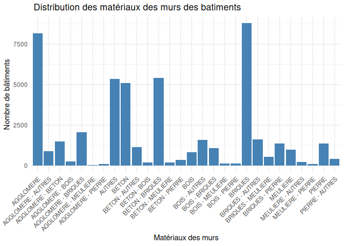

On constate que les matériaux les plus utilisés pour les murs sont les briques et l’aggloméré.

#### Matériaux des toits:

On utilisera les variables matériaux toits.

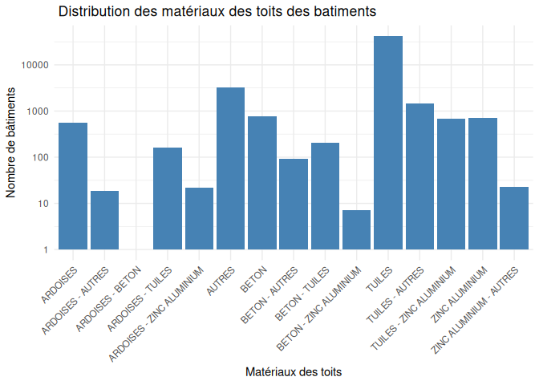

On constate que le matériau le plus utilisé pour les toits est les tuiles.

### Distribution des hauteurs

L’objectif est de voir la distribution des bâtiments en fonction de la hauteur des bâtiments.

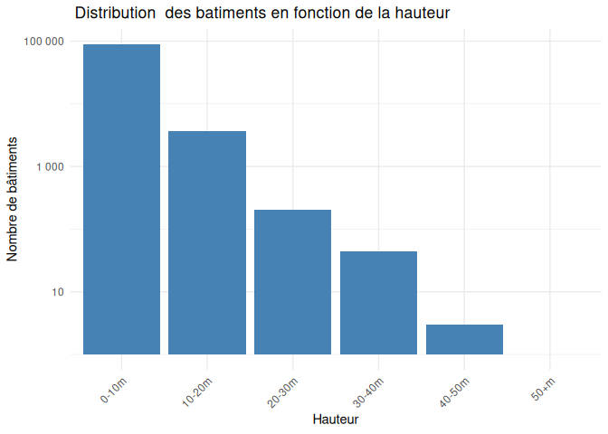

On remarque que la plupart des bâtiments ont une hauteur située entre 0 et 10m.

### Distribution des dates de construction

L’objectif est de voir la distribution des bâtiments en fonction de l’année de construction.

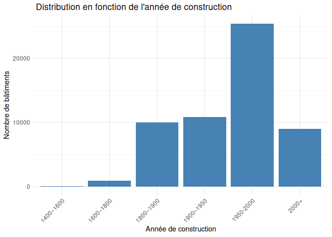

### Distribution en fonction des usages.

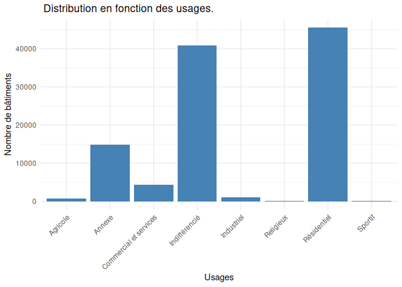

## 1. Lien entre la hauteur des bâtiments et leur usage.

Il s’agit de déterminer s’il existe une relation entre la hauteur d’un bâtiment et son usage. Les variables utilisées sont : la variable `hauteur` et la variable `usage1`.

Résultats attendus :

Nous pensons que :

- Les bâtiments résidentiels seraient majoritairement de petite ou moyenne hauteur
- Les bâtiments à usage commercial ou industriel pourraient être de hauteur élevée

### Visualisation

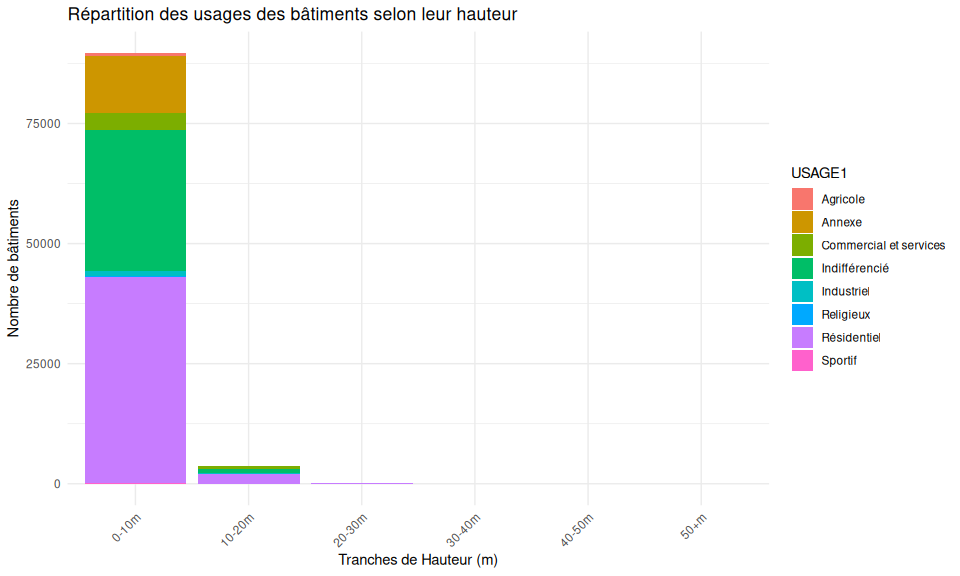

### Interprétation des résultats

Contrairement à l’hypothèse de départ, la plupart des bâtiments à usage commercial ont une hauteur inférieure à 10 m. Cela s’explique par le fait que les commerces sont intégrés en rez-de-chaussée des bâtiments résidentiels.

## 2. Expansion de la ville de Troyes au fil du temps

Nous voulons voir si les bâtiments si les bâtiments ont été construits de plus en plus loin du centre de Troyes au fil des années ou si cela a peu d’influence.  
Les variables utilisées sont : `date_app`, `longitude` et `latitude`.

Nous pensons que :

- Les bâtiments dans le centre sont les plus vieux
- Il y a des vieux bâtiments aussi autour de Troyes

### Visualisation

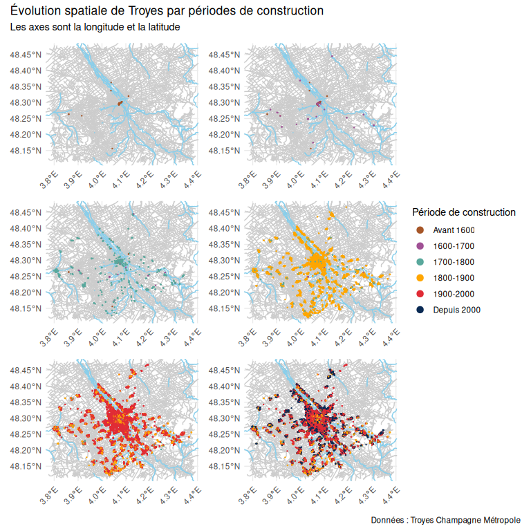

### Interprétation des résultats

Il est difficile de connaître la date de construction des bâtiments qui ont été construits avant 1600, d’où le manque d’information. J’ai dû masquer tous les bâtiments dont on a pas la date de construction car cela nuisait à la lisibilité du graphique.

On remarque la construction de beaucoup de bâtiments entre 1700 et 1800, puis une assez grosse expansion entre 1800 et 1900. On remarque aussi que l’agglomération de Troyes avait sa forme assez tôt et que même si elle s’est densifiée, elle ne s’est pas vraiment étendue.

## 3. Y a-t-il un lien entre les matériaux de construction et les dates de construction ?

### Murs

L’objectif ici est de comprendre si l’utilisation des matériaux changent selon les époques. Pour cela nous allons réaliser une heatmap liée aux matériaux des murs.

Les variables utilisées sont :

- MAT_MURS: variable nominal: code des matériaux des murs, croisé avec materiaux_murs.csv
- DATE_APP: variable discrète d’apparition des bâtiments

Nous nous attendons à ce que les matériaux les plus solides de chaque époque soit utilisés successivement.

### Visualisation

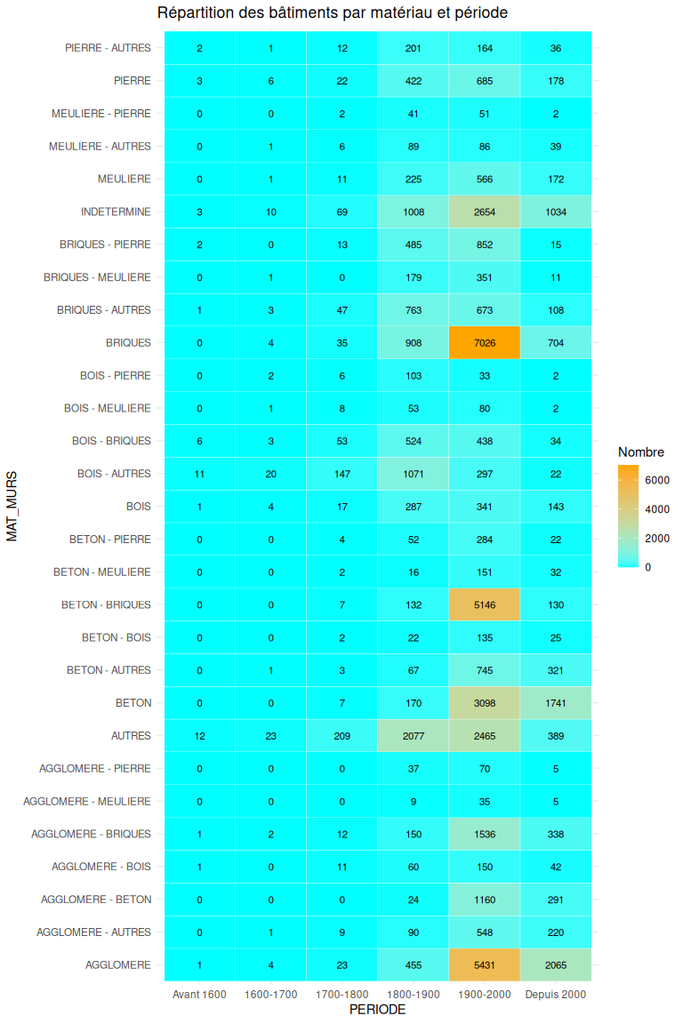

### Interprétation des résultats

Tout d’abord, il faut préciser que nous manquant de beaucoup d’information, particulièrement sur les années avant 1800. Il est donc difficile de généraliser les informations du graphe. De plus, un certain nombre de bâtiments n’ont pas de matériaux connus. Nous passons donc de 107 946 observations à 59097 observations. Cependant, nous pouvons voir des tendances se dégager. Certains matériaux sont présent depuis avant 1600, comme l’aggloméré et le bois. D’autres ont connu des pics de popularité récents, comme le béton, la brique et l’aggloméré. On peut aussi remarqué l’utilisation massive de la pierre autours des années 1900 mais s’est raréfié depuis. Même si certains matériaux s’imposent à certaines époques, on peut voir qu’il y a une diversité de ceux-ci et beaucoup de mélange de matériaux.

### Toits

L’objectif ici est de comprendre si l’utilisation des matériaux changent selon les époques. Pour cela nous allons réaliser une heatmap liée aux matériaux des toits.

Les variables utilisées sont :

- MAT_TOITS: variable nominal: code des matériaux des murs, croisé avec materiaux_toits.csv
- DATE_APP: variable discrète d’apparition des bâtiments

### Visualisation

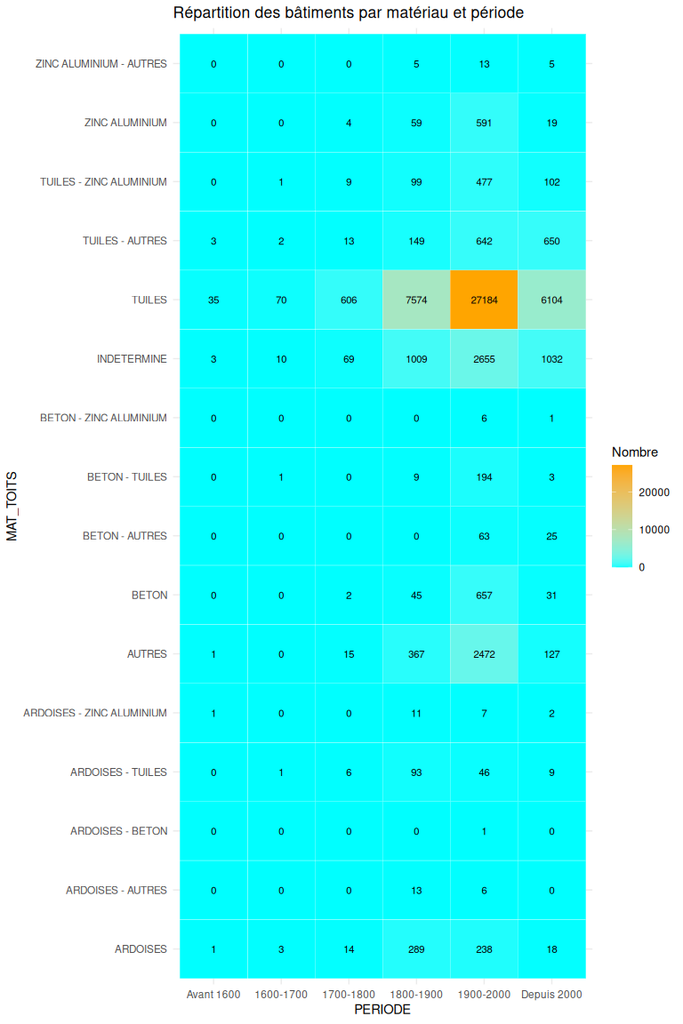

## 6. ALEXIS - L’année de construction a-t-elle un impact sur l’usage d’un bâtiment?

### Exposition du problème:

L’objectif de cette exploration est de comprendre s’il existe une relation entre l’année de construction d’un bâtiment et son usage principal. Cette question soulève une hypothèse simple mais pertinente : les usages des bâtiments évoluent dans le temps, en lien avec les dynamiques urbaines.

**On peut ainsi supposer que :**

- Certains usages récents comme les bâtiments commerciaux ou industriels spécialisés sont associés à des constructions récentes
- Les bâtiments religieux sont tous anciens, à cause de la nature historique et du fait que l’on n’évite de les détruire pour en construire de nouveaux.
- Les bâtiments d’habitations sont répartis sur toute la période historique.

**Nous mobiliserons ces variables:**

- La variable `date_app`, qui indique la date de construction (d’apparition) du bâtiment.
- Les variables `usage1` (et éventuellement `usage2`), qui décrivent la ou les fonctions principales du bâtiment.

### Visualisation:

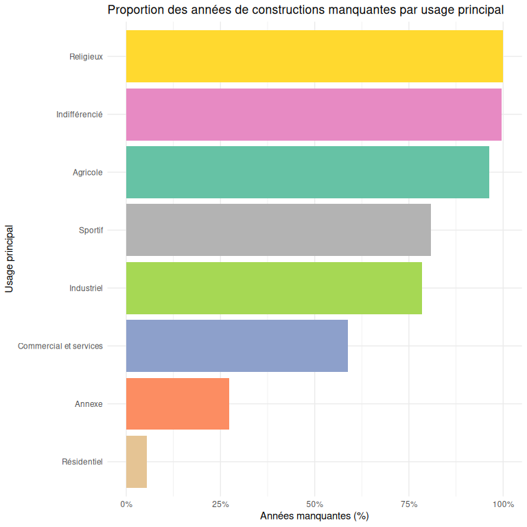

Nombre de bâtiments avec une année de construction disponible par usage

| USAGE1 | Nombre avec date | Nombre total |
| --- | --- | --- |
| Résidentiel | 43091 | 45556 |
| Indifférencié | 146 | 40946 |
| Annexe | 10831 | 14918 |
| Commercial et services | 1818 | 4413 |
| Industriel | 238 | 1108 |
| Agricole | 27 | 744 |
| Religieux | 0 | 151 |
| Sportif | 21 | 110 |

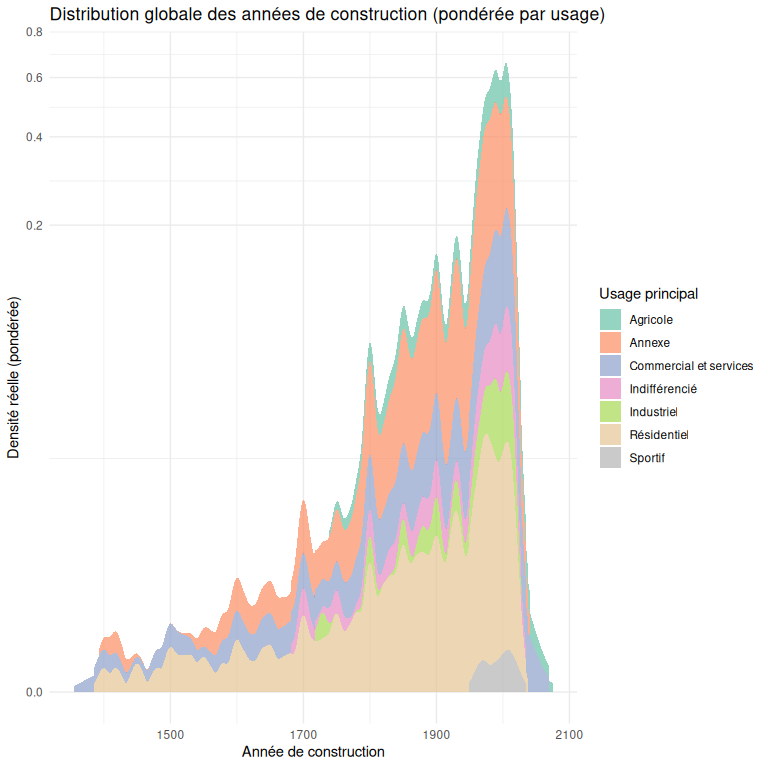

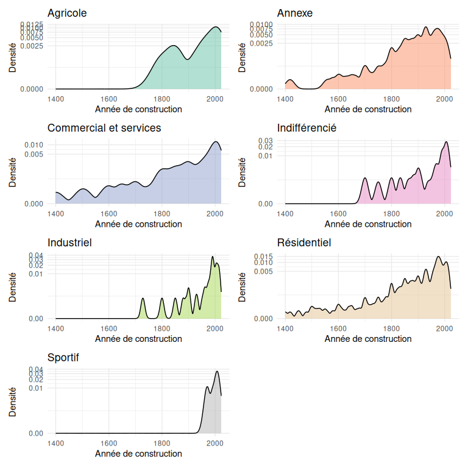

### Interprétation des résultats:

Tout d’abord, on remarque dans le premier bargraphe que aucun bâtiment religieux n’a de date de construction et qu’une grande majorité des bâtiments indifférencié, agricole, sportif et industriel n’en ont pas non plus. Suite à cela j’ai établi un tableau donnant le nombre de bâtiment ayant une date de constructions par rapport aux nombre total par usage afin de voir si les visualisations suivantes seront significatives.

On remarque dans le tableau que le nombre est faible pour les bâtiments agricole et indifférencié, il faut donc prendre du retrait sur ces usages et leur graphique.

- Après quelques recherches sur un échantillon de ses bâtiments indifférenciés, nous avons remarquer que cela correspond a des bâtiments, souvent de grande taille et ayant subit beaucoup d’extensions ou de travaux comme l’hôpital ou des bâtiments public comme la préfecture, d’autres sont tout simplement en ruine. Il est donc compréhensible que les informations dans la base de données soit incomplètes.
- Concernant les bâtiments agricoles, on se retrouve sur presque la même situation, ces bâtiments sont vieux et ayant obtenu des extensions. Il est donc difficile de les dater.

Concernant les diagrammes de densité, il est important de précisé que l’échelle de l’axe des ordonnées est en `sqrt^4` , cette transformation est faite afin de pouvoir observer tous les usages de bâtiments et que les années récentes ne rende pas la lecture difficile (les constructions étant beaucoup plus fréquentes):

- Le premier est un diagramme de densité pondéré
- Le second, un semble de diagramme de densité pour chaque usage.

## X. Y a-t-il une corrélation entre les matériaux de construction et la hauteur du bâtiment ?

L’objectif ici est de comprendre si l’évolution des matériaux, principalement des murs a un impact sur la hauteur des bâtiments. Pour cela, nous allons réaliser deux violinplot, l’un lié au matériau des murs et l’autre des toits afin de confirmer une corrélation.

Les variables utilisées sont :

- MAT_MURS : variable nominale : code des matériaux des murs, croisé avec materiaux_murs.csv
- MAT_TOITS : variable nominale : code des matériaux de la toiture, croisé avec materiaux_toits.csv
- HAUTEUR : variable continue représentant la hauteur absolue du bâtiment

Nous nous attendons à ce que les matériaux plus modernes et denses comme le béton ( au niveau des murs et aussi de la toiture ) composent les bâtiments les plus hauts de l’agglomération troyenne. De, plus nous pensons que le matériau des murs aura plus d’influence que celui de la toiture.

### Visualisation

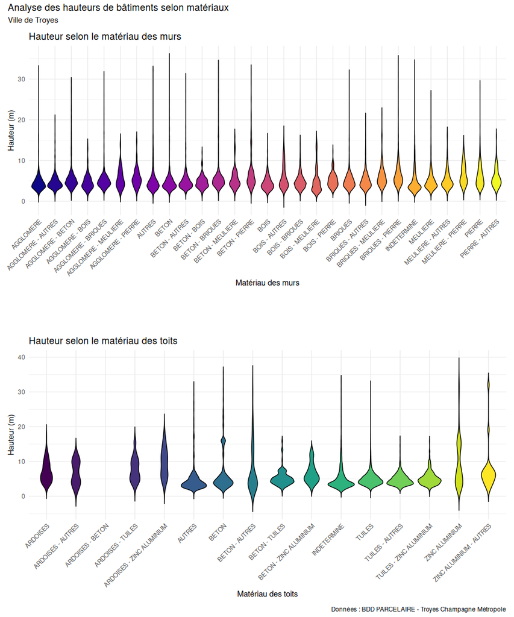

### Interprétation des résultats

Tout d’abord, quand l’on regarde le graphique de la hauteur par rapport aux matériaux des murs, il est difficile d’observer une corrélation. En effet, on remarque de très faibles différences dans la distribution des hauteurs pour chaque combinaison de matériau. Cela pourrait amener à penser que le matériau des murs n’a pas une influence déterminante sur la hauteur des bâtiments, du moins d’après cette visualisation. Une approche complémentaire, comme représenter la hauteur moyenne ou médiane pour chaque matériau, pourrait nous apporter des réponses plus claires et mettre en évidence des tendances qui peuvent être plus légères.

## 8. Quel est la part de maison (1 seul logement dans le bâtiment) et d’appartement parmis les résidences?

Variables utilisées: NB_LOGTS (nombre de logements par batiment), USAGE1 et USAGE2 Moyenne nationale selon FNAIM: 55% de maison, 45% d’appartement Moyenne dans l’Aube selon FNAIM: entre 20% et 40% d’appartement Qu’en est-il de Troyes?

### Visualisation

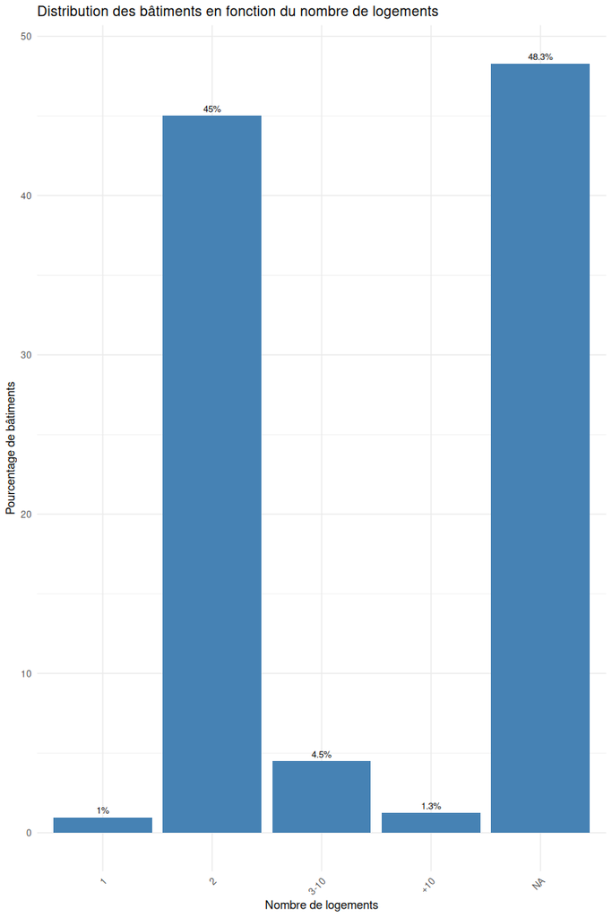

## 9. Quel est la part de batiments résidentiels à 2 logements sont aussi commerciaux?

###Visualisation

Pour USAGE1:

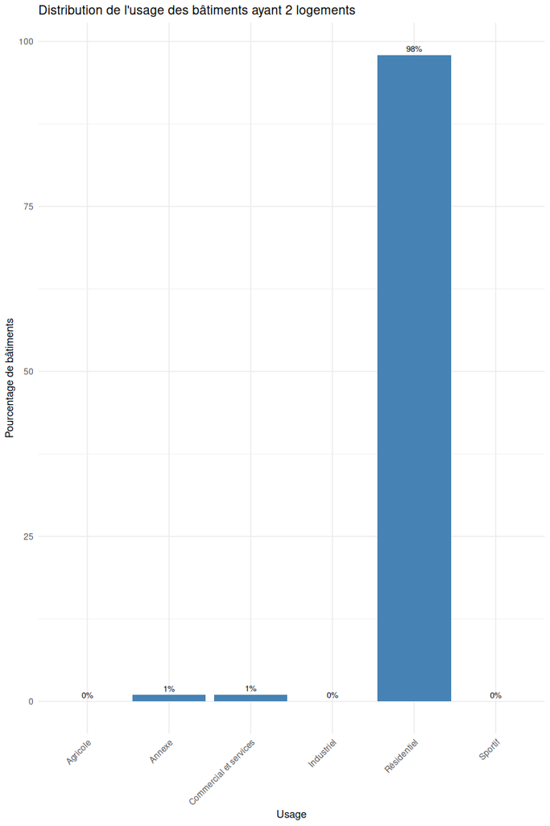

Pour USAGE2:

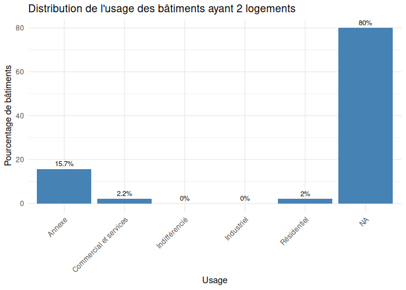

### Interpretation En cumulant le pourcentage de bâtiments ayant residentiels en USAGE1 et commercial en USAGE2 et inversement (commercial en USAGE1 et residentiel en USAGE2), on tombe sur 3,2% des bâtiments ayant 2 logements sont résidentiels et commerciaux. Cela infirme l’hypothèse que le fort nombre de bâtiments résidentiels à 2 logements est dû aux commerces.

# **Conclusion**

# Annexe

Alexis H:

- Réalisation des questions 5,6 et 7 dans le plan d’analyse et dans l’exploration.
- Réalisation des travaux sur Tableau

Alexis M:

Camille:

Danielle: